# Przykłady

Michał Burdukiewicz

14-12-2024

Źródło danych: https://github.com/michbur/polish-driver-license

## Rysunek 1

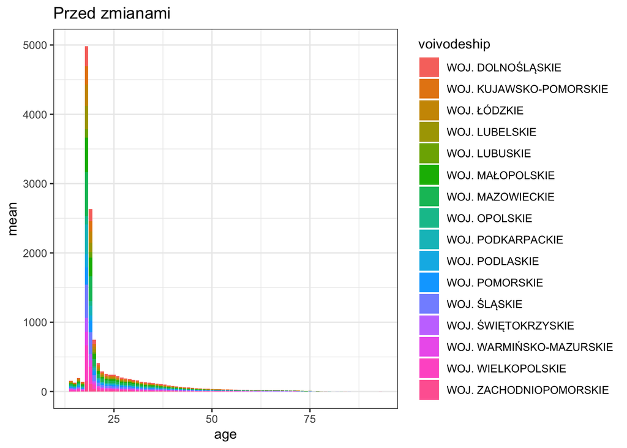

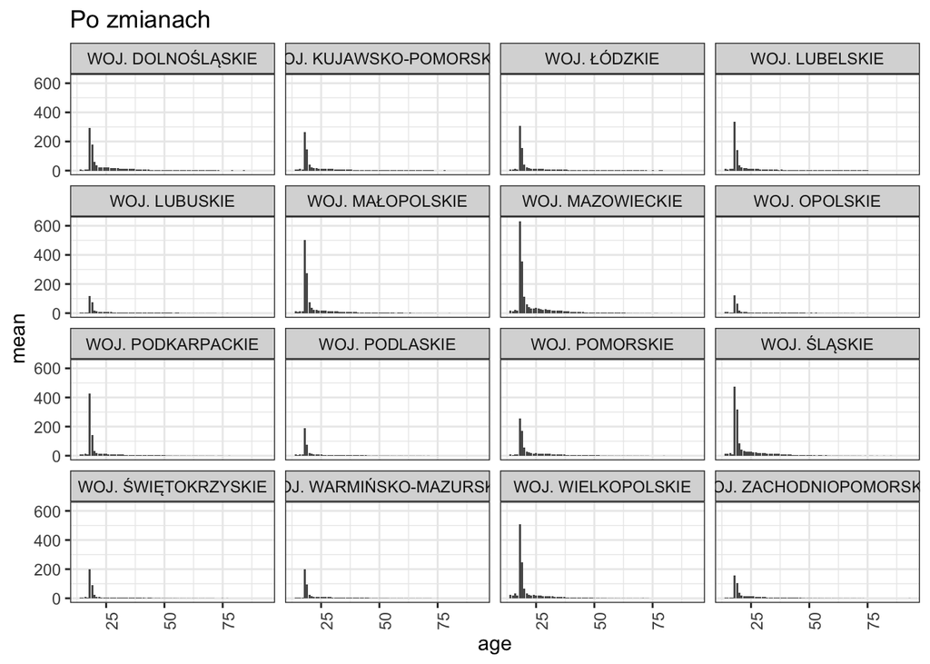

Cel: pokazanie średniej liczby osób, które uzyskały prawo jazdy w danym wieku w zależności od województwa.

Po pierwsze proponujemy zbudować biny z przedziałami wiekowymi,

np.: -25, 26-35, 36-45, 46-55, 56-

oś X: średnia

oś Y: przedziały (biny)

jak zrobimy biny to moim zdaniem będą duże dysproporcje między tym do 25 a resztą

Alternatywne rozwiązanie - Rozbić wykres na poszczególne województwa lub zaprewzentować każde województwo w formie linii by dało się porównać województwa (16 linii będzie nieczytelne!)

atrybuty wizualne:

oś X: wiek oś Y: średnia z lat kontrastowe kolory pomiędzy poszczególnymi słupkami przedziały wiekowe co 9 lat geometria: słupki

facety po województwach

statystyka: średnia

Może zróbmy tu głosowanie (wstawcie 1 przy pomyśle)? ok 1) biny +1 2) facety +1+1+1 3) linie dla kazdego woj

## Rysunek 2

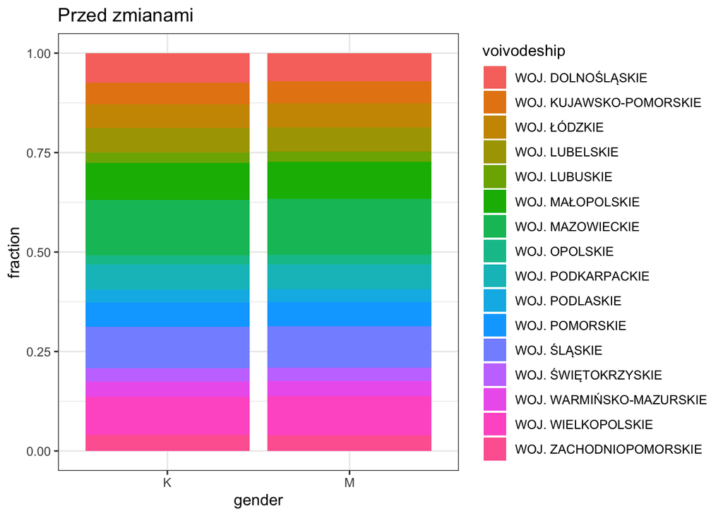

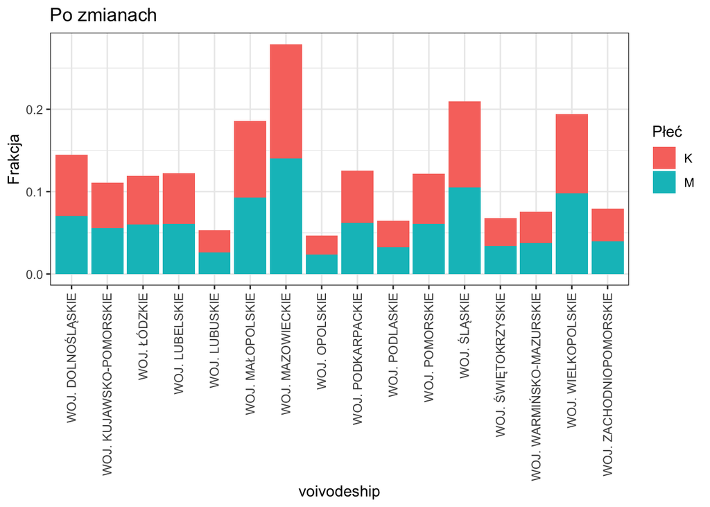

Cel: pokazanie frakcji kobiet i mężczyzn uzyskujących prawo jazdy w danym województwie.

atrybuty wizualne:

oś y: frakcji kobiet i mężczyzn uzyskujących prawo jazdy w danym województwie

oś x: województwa (dane uszeregowane od największy do najmniejszy, sumujące się do 100 %)

kolory: płeć (z odpowiednimi kolorami, kontrast)

dodatkowo: procenty na słupkach (w połowie wysokości), wszystko w jednym języku, nazwy województw pod kątem 90 st, tytuł wykresu na górze

geometria: słupki skumulowane

facety: nie (ew. podział na kobiety i mężczyzn dla całości i dla poszczególnych województw)

statystyka: frakcja

## Rysunek 3

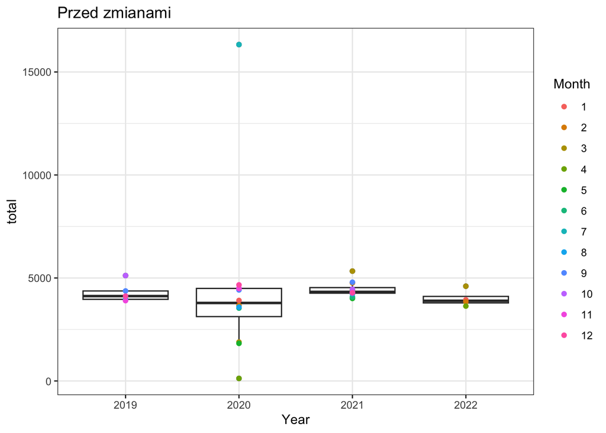

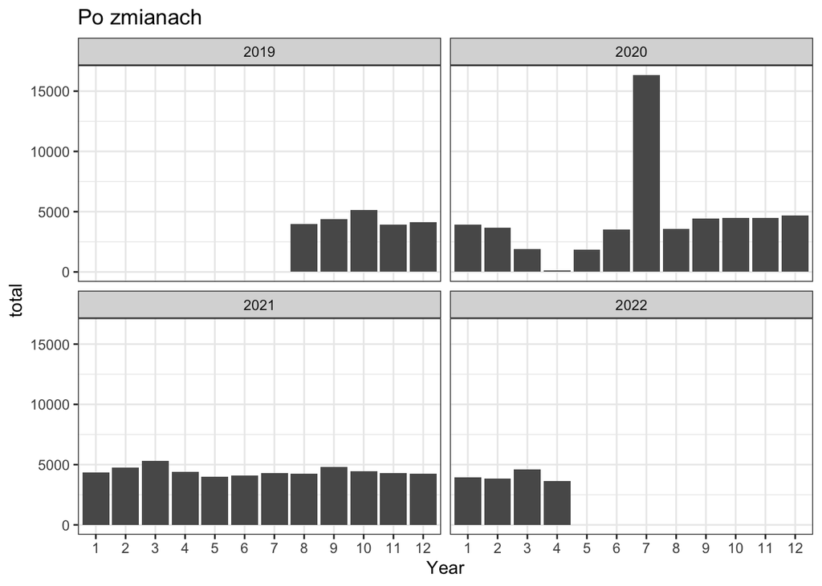

Cel: pokazanie zmienności liczby uzyskanych praw jazdy w skali roku w zależności od roku w województwie mazowieckim.

Atrybuty Wizualne: Osie x (miesiąc) oraz y (total).

Geometria:

Fasety: rozdzielenie wykresu na 4 fasety każdy rok osobno z podziałem namiesiące. Przedstawienie danych w formie wykresu słupkowego

Statystyki: przedtsawienie mediany poprzez wartość stałą liniową na wykresie (linia przerywana)

Atrybuty wizualne:

Zmiana na fasety (każdy rok osobno)

Zmiana osi x na miesiące

Oś y zostaję jako total (iloś praw jazdy wydanych) z woj. Mazowieckim.

Zmiana na słupki (miesiące)

Geomeria:

Słupki

Dodac label totalu nad słubkami

Ucięte osie (Pomysł jak sobie poradzic z outlier-em w 2020 roku)

Fasety:

Podział danych na 4 lata/fasety

Statystyka:

Średnia/mediana w roku

## Rysunek 4

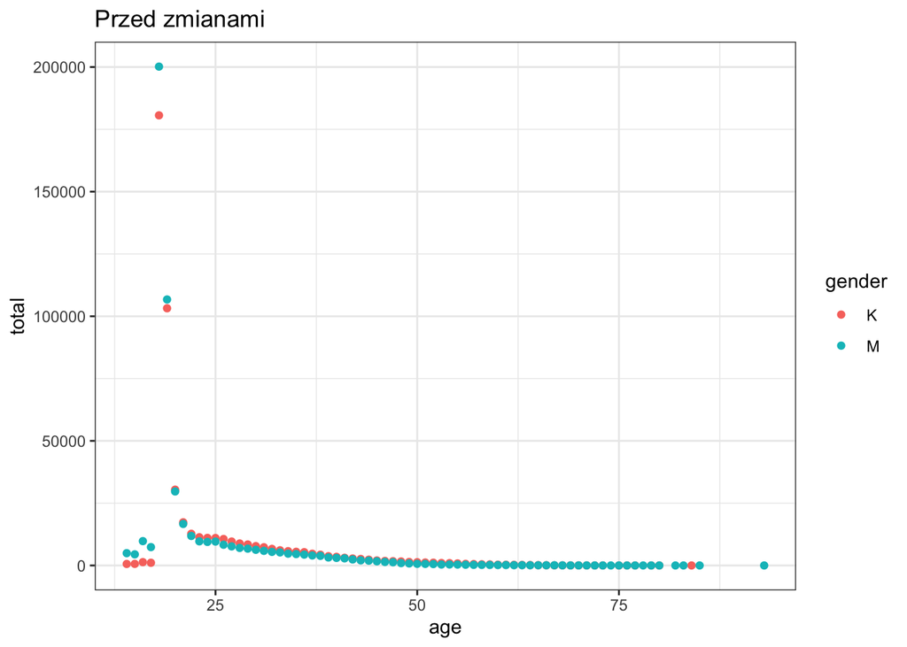

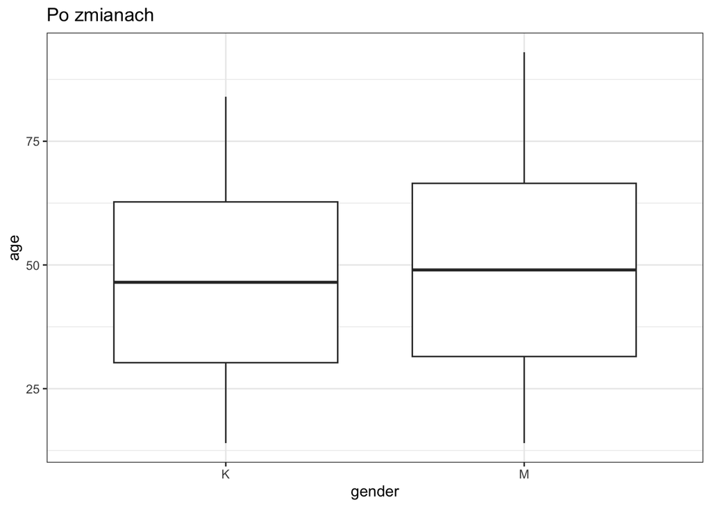

Cel: pokazać zależność liczby uzyskanych praw jazdy w zależności od wieku i płci.

Pomysł 1

atrybuty wizualne: nadal dwie osie

geometria: dwukolorowe słupki warstwowe (po jeden na każdy wiek)

fasety: podział na grupy wiekowe (np. cztery: 14-17 (wyjątkowo młodzi), 18-20 (typowi), 21-50, 51-100 (“seniorzy”)) - ewentualnie podział tak, żeby były cztery równe grupy; różna skala, tak żeby było widać zróżnicowanie - może być mylące ?

statystyka: liczba osób w danym wieku, które uzyskały prawo jazdy

Pomysł 2 - OSTATECZNY

atrybuty wizualne: na osi x dwie kategorie: kobiety i mężczyźni; na osi y wiek

geometria: pudełkowy wykres kobiety vs. mężczyźni

statystyka: mediana, kwartyle, przedział ufności 95%, wartości odstające wieku osób danej płci, w którym uzyskały prawo jazdy

## Rysunek 5

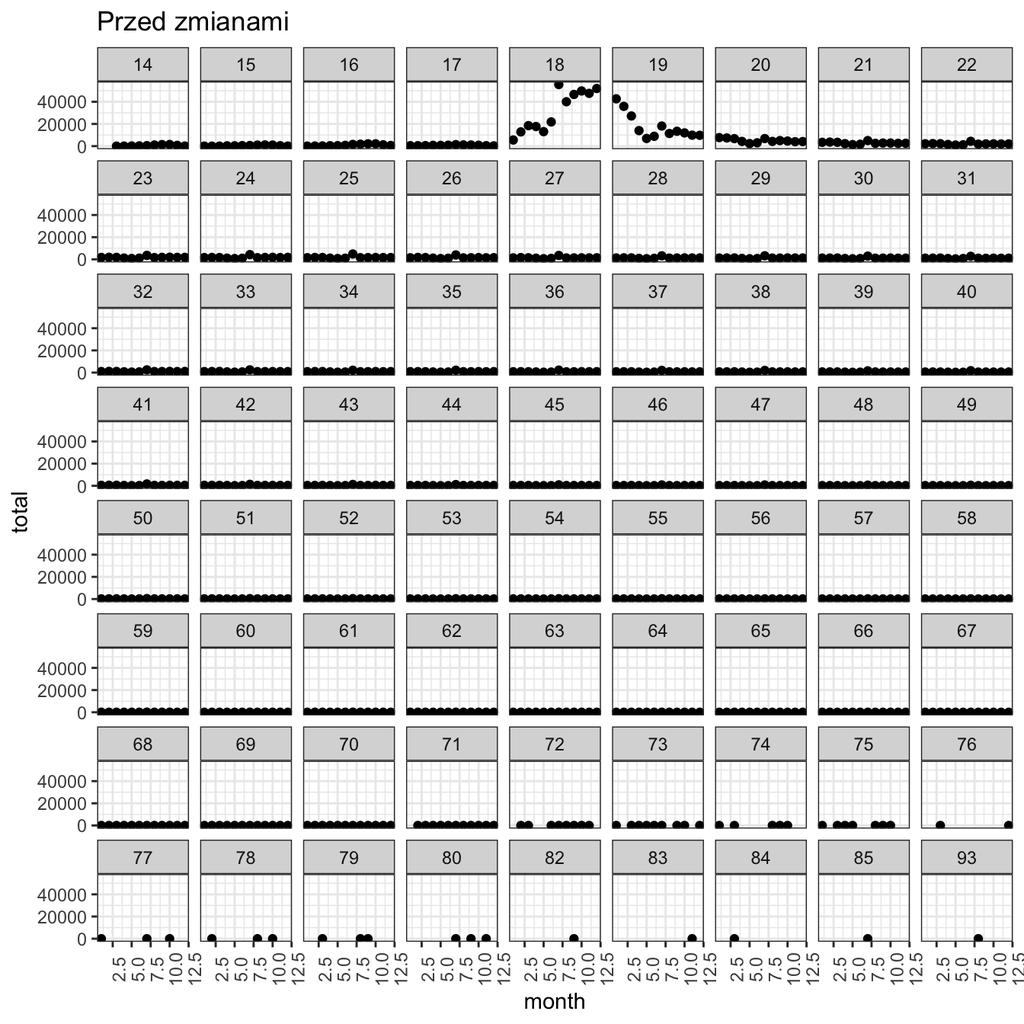

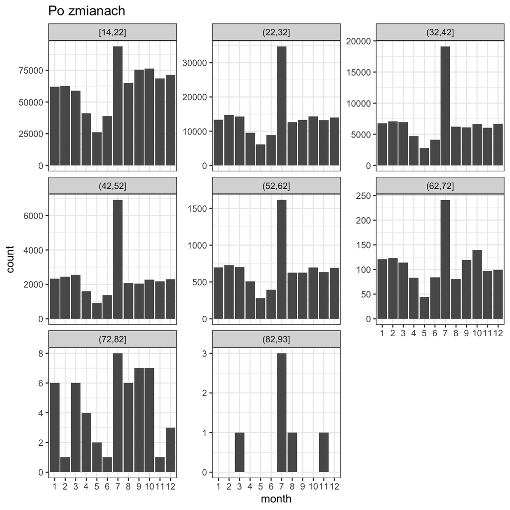

Cel: pokazać liczbę praw jazdy uzyskiwanych przez osoby w różnym wieku w zależności od miesiąca.

pomysł 1 - poprawiamy ten wykres co jest tj. punktowy fasetowy ale:

dane: grupujemy dane po wieku, co 9 lat tj. 8 grup wiekowych - 8 fasetów

atrybuty wizualne: modyfikujemy oś x tak by pokazywała miesiace (nazwy lub skróty nazw) i tak by każdy faset miał oś x widoczną

opisujemy oś y zamiast total to ilośc osób które zdały egzamin

pomysł 2, preferowany:

Zmieniamy typ wykresu na słupkowy skumulowany gdzie osi są jak wyżej tj. oś x tak by pokazywała miesiace (nazwy lub skróty nazw) i tak by każdy faset miał oś x widoczną, oś y zamiast total to ilośc osób które zdały egzamin

dane: Grupowanie fasetów co 9 lat (8 grup)

atrybuty wizualne:wykres słupkowy skumulowany, do rozważenia skala logarytmiczna (pierwsza grupa danych z wiekiem 14-22), dodanie legendy z opisem przedziałów (grup)

geometrie: słupki

fasety: podział co 9 lat, skala z miesiącami dodana do każdego faseta

statystyk: mediana na dany miesiac, jeden wykres z 12 słupkami dla każdego z miesięcy (podzielonych wedle udziału przyjętych grup wiekowych)

## Rysunek 6

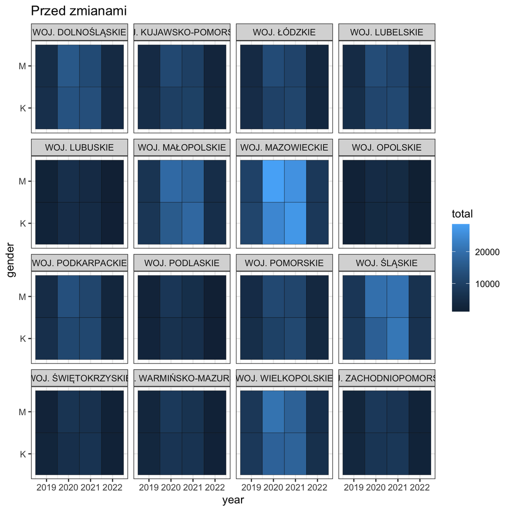

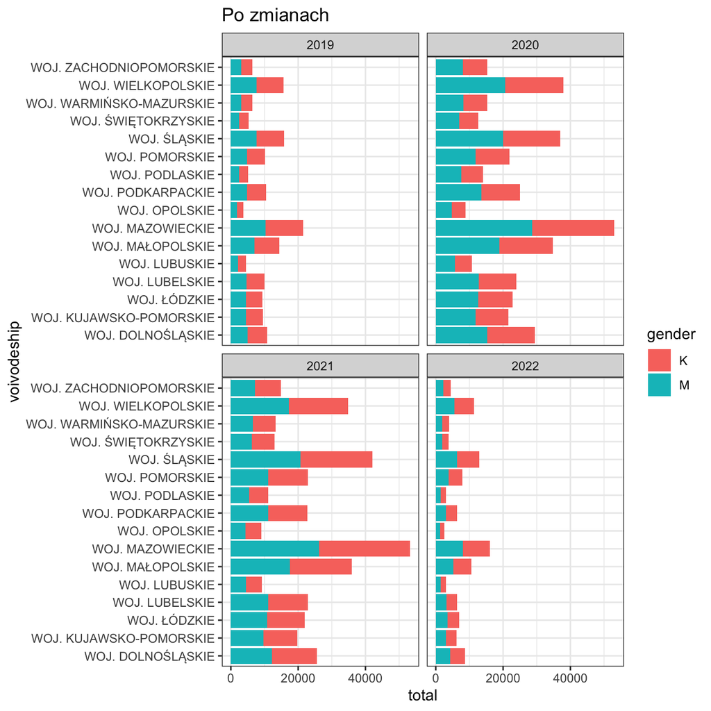

Cel: pokazać liczbę uzyskanych praw jazdy dla poszczególnych województw w zależności od płci i roku.

dane: wykres fasetowy słupkowy orientacja pionowa ze względu na rok 2019-2020-2021-20222

geometria: wykres słupkowy

atrybuty wizualne: dana płeć okreslona jest kolorem np kobieta czerwony, mężczyzna niebieski

statystyka: wykreślenie na każdym fasecie linii poziomej oznaczając uśrednioną po województwach ilość zdobytych praw jazdy

co zyskujemy:

redukujemy ilość wyresów z 16 do 4

przejrzysta kolorystyka

wykres słupkowy wprost obrazujący ilość uzyskanych praw jazdy z porównaniem do wartości sredniej w danym roku, z podziałem na płcie

statystyka łatwa do odczytania